# LAD changes after H3K27me3 depletion

Tom van Schaik

2022-02-08

### Project description

Effect of cohesin looping on genome architecture, from the perspective of the nuclear lamina.

### Introduction

I have previously looked at LAD changes after the depletion experiments. Now I want to make a few similar plots after H3K27me3 and a double depletion.

### Method

Use LAD domains as defined previously.

### Set-up

Load the libraries and set the parameters.

```r
# Load dependencies
suppressPackageStartupMessages(library(tidyverse))
suppressPackageStartupMessages(library(GenomicRanges))
suppressPackageStartupMessages(library(rtracklayer))
suppressPackageStartupMessages(library(ggplot2))
suppressPackageStartupMessages(library(UpSetR))
suppressPackageStartupMessages(library(ggbeeswarm))
suppressPackageStartupMessages(library(caTools))
suppressPackageStartupMessages(library(GGally))
suppressPackageStartupMessages(library(corrr))
suppressPackageStartupMessages(library(RColorBrewer))
suppressPackageStartupMessages(library(colorspace))
suppressPackageStartupMessages(library(ggrastr))

# Prepare output
output.dir <- "ts220121_LAD_changes_after_H3K27me3_depletion"
dir.create(output.dir, showWarnings = FALSE)
```

Knitr setup.

```r
library(knitr)
opts_chunk$set(fig.width = 10, fig.height = 4, cache = T,
               message = F, warning = F,
               dev=c('png', 'pdf'), fig.path = file.path(output.dir, "figures/"))
pdf.options(useDingbats = FALSE)
```

List functions.

```r
LoadDamID <- function(metadata, damid.dir, column = "file") {

  # Load data
  tib <- purrr::reduce(lapply(1:nrow(metadata),
                              function(i) {
                                f <- metadata[i, ] %>% pull(column)
                                s <- as.character(metadata$sample)[i]
                                tmp <- read_tsv(file.path(damid.dir, f),
                                                col_names = c("seqnames", "start", "end", s))
                              }),
                       full_join)

  # Convert to GRanges
  tib$start <- tib$start + 1
  gr <- as(tib, "GRanges")

  # Filter chromosomes
  gr <- gr[seqnames(gr) %in% c(paste0("chr", 1:22), "chrX")]
  gr

}

ScaleDamID <- function(damid) {
  tib <- as_tibble(mcols(damid))
  tib.scaled <- as_tibble(scale(tib))
  mcols(damid) <- tib.scaled
  damid
}

LADScores <- function(damid, gr, samples) {
  # Calculate mean scores per LAD, given a LAD model

  # Find overlaps
  ovl <- findOverlaps(damid, gr, select = "first")

  # Calculation
  tib <- as_tibble(mcols(damid)) %>%
    dplyr::select(samples) %>%
    add_column(LAD = ovl) %>%
    drop_na(LAD) %>%
    group_by(LAD) %>%
    summarise_all(mean, na.rm = T) %>%
    dplyr::select(-LAD)

  mcols(gr) <- tib
  gr

}

# From Fede:
# ggpairs custom functions
corColor <- function(data, mapping, color = I("black"), sizeRange = c(1, 3), ...) {

  x   <- eval_data_col(data, mapping$x)
  y   <- eval_data_col(data, mapping$y)
  r   <- cor(x, y)
  rt  <- format(r, digits = 3)
  tt  <- as.character(rt)
  cex <- max(sizeRange)

  # helper function to calculate a useable size
  percent_of_range <- function(percent, range) {
    percent * diff(range) + min(range, na.rm = TRUE)
  }

  # plot correlation coefficient
  p <- ggally_text(label = tt, mapping = aes(), xP = 0.5, yP = 0.5,
                   # size = I(percent_of_range(cex * abs(r), sizeRange)),
                   size = 6,
                   color = color, ...) +
    theme(panel.grid.minor=element_blank(),
          panel.grid.major=element_blank())

  corColors <- RColorBrewer::brewer.pal(n = 7, name = "RdYlBu")[2:6]

  if (r <= boundaries[1]) {
    corCol <- corColors[1]
  } else if (r <= boundaries[2]) {
    corCol <- corColors[2]
  } else if (r < boundaries[3]) {
    corCol <- corColors[3]
  } else if (r < boundaries[4]) {
    corCol <- corColors[4]
  } else {
    corCol <- corColors[5]
  }

  p <- p +
    theme(panel.background = element_rect(fill = corCol))

  return(p)
}

customScatter <- function (data, mapping)
{
    p <- ggplot(data = data, mapping) +
      rasterize(geom_point(size = 0.25, alpha = 0.25),
                dpi = 300) +
      #geom_smooth(method = "lm", se = T, col = "red") +
      theme_bw()

    p
}
```

### 0. H3K27me3 depletion

Make a plot in R for the H3K27me3 depletion as estimated by western blot (by Ste).

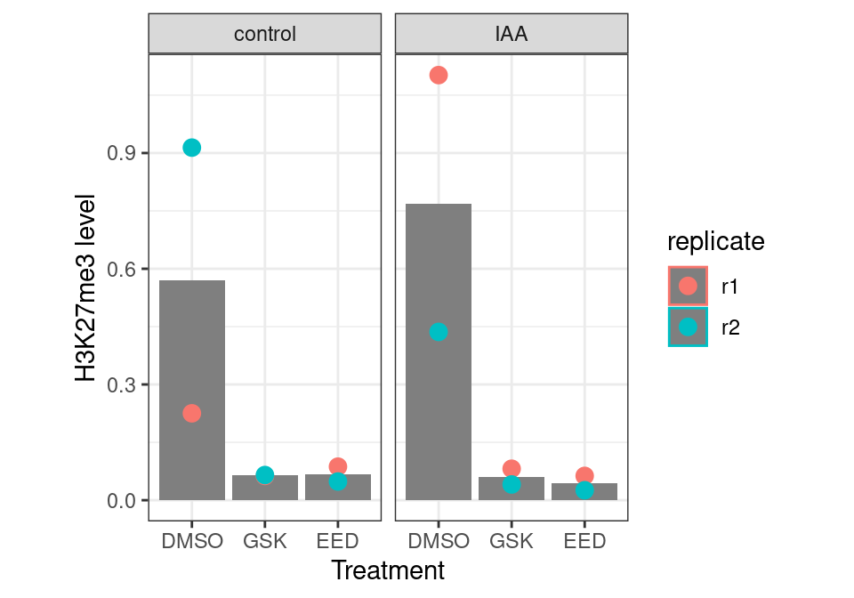

```r
# Data input
h3k27me3_depletion <- tibble(sample = paste(rep(c("DMSO_control",
                                                  "EED_control",
                                                  "GSK_control",
                                                  "DMSO_IAA",
                                                  "EED_IAA",
                                                  "GSK_IAA"),
                                                times = 2),
                                            rep(c("r2", "r1"),
                                                each = 6),
                                            sep = "_"),
                             absolute = c(0.914084372,
                                          0.048421751,
                                          0.065179744,
                                          0.436338494,
                                          0.025772122,
                                          0.040758301,
                                          0.225226237,
                                          0.086944998,
                                          0.062907913,
                                          1.102112394,
                                          0.062982975,
                                          0.081537619)) %>%
  separate(sample, c("treatment", "depletion", "replicate"), remove = F) %>%
  mutate(treatment = factor(treatment, c("DMSO", "GSK", "EED")),
         depletion = factor(depletion, c("control", "IAA")),
         replicate = factor(replicate, c("r1", "r2"))) %>%
  arrange(replicate, treatment, depletion)

# Plot
h3k27me3_depletion %>%
  ggplot(aes(x = treatment, y = absolute, col = replicate)) +
  stat_summary(fun = mean, aes(group = interaction(treatment, depletion)),
               geom = "bar", fill = "grey50") +
  geom_point(size = 3) +
  facet_grid(. ~ depletion) +
  xlab("Treatment") +
  ylab("H3K27me3 level") +
  theme_bw() +
  theme(aspect.ratio = 2)
```

### 1. Load data

Load the required data.

#### 1.1 Previous objects

First, simply objects from previous documents.

```r
# Read .rds files
input.dir <- "ts220113_DamID_changes_versus_LAD_size_and_score"
#LADs_consensus <- readRDS(file.path(input.dir, "LADs_consensus.rds"))
LADs_consensus <- readRDS(file.path(input.dir, "LADs_list_individual.rds"))[["CTCFEL"]]
```

#### 1.2 DamID

Read the DamID data - only combined objects.

```r
# First, prepare metadata
metadata_h3k27me3 <- tibble(file = dir("../results_NQ/normalized/bin-10kb/",
                                       pattern = "EL_.*combined")) %>%
  mutate(sample = str_remove(file, "-10.*"),
         sample = str_remove(sample, "pADamID_"),
         sample = str_replace_all(sample, "-", "")) %>%
  # add conditions
  mutate(condition = case_when(grepl("DMSO", sample) ~ "DMSO",
                               grepl("GSK", sample) ~ "GSK",
                               grepl("EED", sample) ~ "EED",
                               T ~ "control"),
         condition = factor(condition, c("control", "DMSO", "GSK", "EED")),
         timepoint = case_when(grepl("IAA", sample) ~ "24h",
                               T ~ str_remove(sample, ".*_"))) %>%
  # filter samples
  filter(timepoint %in% c("0h", "24h")) %>%
  # rename samples
  mutate(sample = paste(condition, timepoint, sep = "_"))

# Then, load DamID
damid_h3k27me3 <- LoadDamID(metadata = metadata_h3k27me3,
                            damid.dir = "../results_NQ/normalized/bin-10kb/")
damid_h3k27me3 <- ScaleDamID(damid_h3k27me3)
```

Finally, determine LAD scores - mean score per LAD per condition.

```r
# Determine LAD scores
lad_scores <- LADScores(damid = damid_h3k27me3, gr = LADs_consensus,
                        samples = metadata_h3k27me3$sample)
```

### 2. LAD differences with control and over time

I have now generated data in control cells (no treatment), DMSO (negative control) and two H3K27me3 inhibitors. I will try various ways to plot the data, and select the one that summarizes the observations best.

First, I looked at the differences between undepleted conditions.

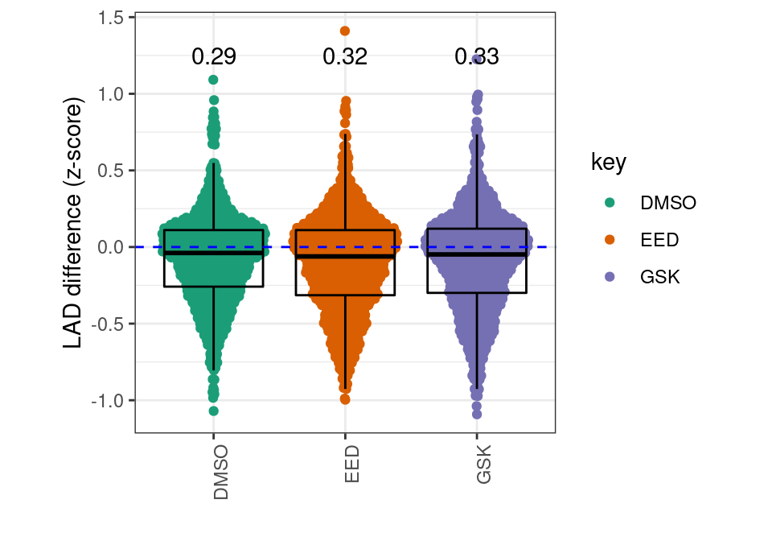

```r
# Include st-dev in the plot
sd_fun <- function(x){
    return(data.frame(y = 1.25, label = round(sd(x), 2)))
}

# lad differences with control - should be small
tib <- as_tibble(lad_scores)

tib %>%
  mutate(DMSO = DMSO_0h - control_0h,
         GSK = GSK_0h - control_0h,
         EED = EED_0h - control_0h) %>%
  dplyr::select(-ends_with("h"), -start, -end, -strand) %>%
  gather(key, value, -seqnames) %>%
  ggplot(aes(x = key, y = value, col = key)) +
  geom_quasirandom() +
  geom_boxplot(fill = NA, outlier.shape = NA, col = "black") +
  stat_summary(fun.data = sd_fun, geom = "text", col = "black") +
  geom_hline(yintercept = 0, col = "blue", linetype = "dashed") +
  xlab("") +
  ylab("LAD difference (z-score)") +
  scale_color_brewer(palette = "Dark2") +
  theme_bw() +
  theme(aspect.ratio = 1,
        axis.text.x = element_text(angle = 90, hjust = 1))
```

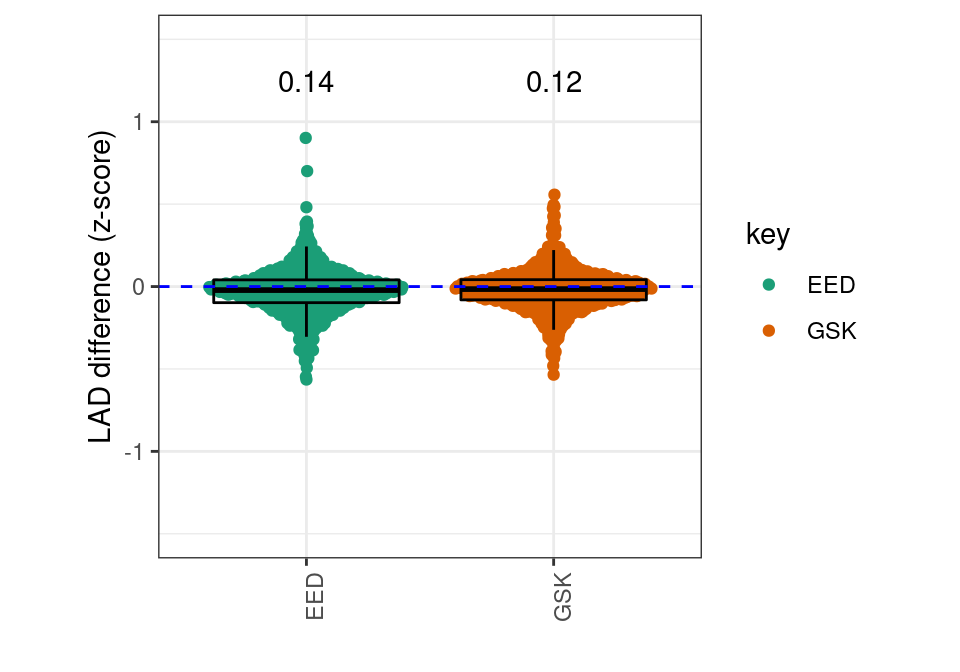

```r
# lad differences with dmso - should be small
tib %>%
  mutate(GSK = GSK_0h - DMSO_0h,
         EED = EED_0h - DMSO_0h) %>%
  dplyr::select(-ends_with("h"), -start, -end, -strand) %>%
  gather(key, value, -seqnames) %>%
  ggplot(aes(x = key, y = value, col = key)) +
  geom_quasirandom() +
  geom_boxplot(fill = NA, outlier.shape = NA, col = "black") +
  stat_summary(fun.data = sd_fun, geom = "text", col = "black") +
  geom_hline(yintercept = 0, col = "blue", linetype = "dashed") +
  xlab("") +
  ylab("LAD difference (z-score)") +
  scale_color_brewer(palette = "Dark2") +
  coord_cartesian(ylim = c(-1.5, 1.5)) +
  theme_bw() +
  theme(aspect.ratio = 1,
        axis.text.x = element_text(angle = 90, hjust = 1))
```

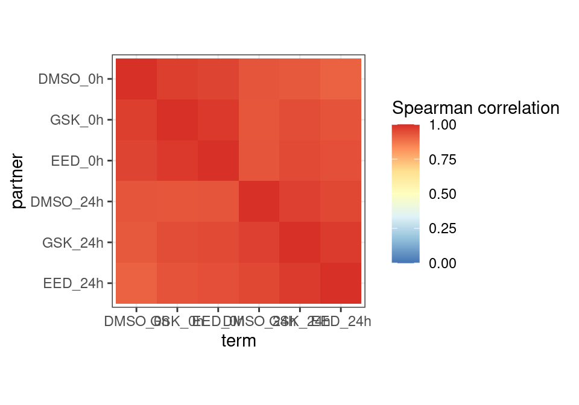

```r
# Heatmap of all correlations
tib %>%
  dplyr::select(contains("DMSO"),
                contains("GSK"),
                contains("EED")) %>%
  dplyr::select(1, 3, 5, 2, 4, 6) %>%
  correlate(method = "spearman", diagonal = 1) %>%
  gather(partner, value, -term) %>%
  mutate(term = factor(term, unique(term)),
         partner = factor(partner, rev(levels(term)))) %>%
  ggplot(aes(x = term, y = partner, fill = value)) +
  geom_tile() +
  scale_fill_gradientn(colors = colorRampPalette(rev(brewer.pal(n = 7,
                                                                name = "RdYlBu")))(100),
                       limits = c(0, 1),
                       name = "Spearman correlation") +
  theme_bw() +
  theme(aspect.ratio = 1)
```

As expected, the control experiment was done independently from these H3K27me3 experiments. As a result, there is significant variation between these 0 h samples and the control 0 h sample.

The correlation plots below summarize a lot of the new data. They nicely illustrate that treatment (24 h after auxin) conditions are very similar. There is not clear indiciation that the two H3K27me3 inhibitor experiments are different from the DMSO condition. This indicates that H3K27me3 depletion does not affect NL interactions.

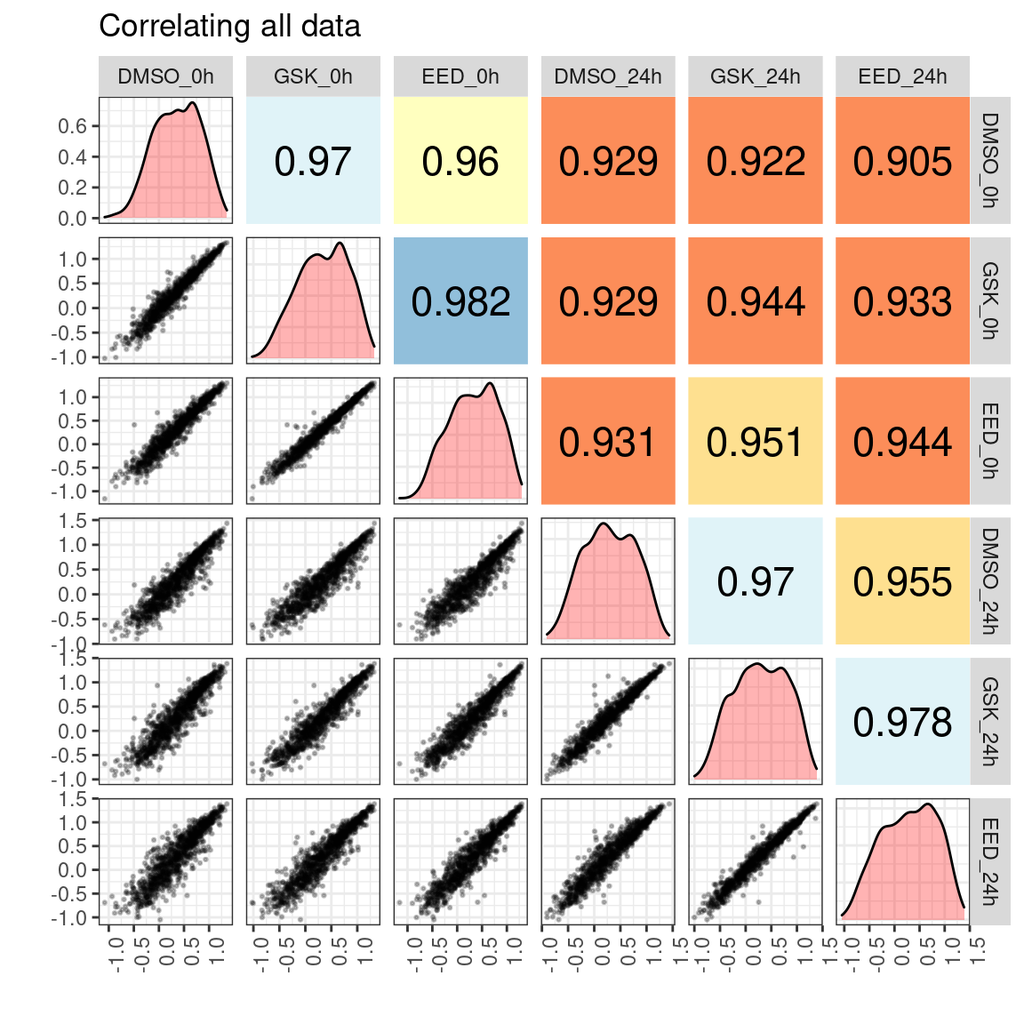

```r
# ggpairs
# Use GGally to make correlation plots
boundaries <- seq(from = 0.95, to = 0.98, length.out = 4)

# Replicates
tib_ggpairs <- tib %>%
  dplyr::select(# contains("control"),
                contains("DMSO"),
                contains("GSK"), contains("EED")) %>%
  drop_na()

plt <- ggpairs(tib_ggpairs[, c(1, 3, 5, 2, 4, 6)],
               upper = list(continuous = corColor),
               lower = list(continuous = customScatter),
               diag = list(continuous = function(data, mapping, ...) {
                   ggally_densityDiag(data = data, mapping = mapping, alpha = 0.3, fill = "red") +
                   theme_bw()})) +
  ggtitle("Correlating all data") +
  xlab("") +
  ylab("") +
  theme(axis.text.x = element_text(angle = 90, hjust = 1))

print(plt)
```

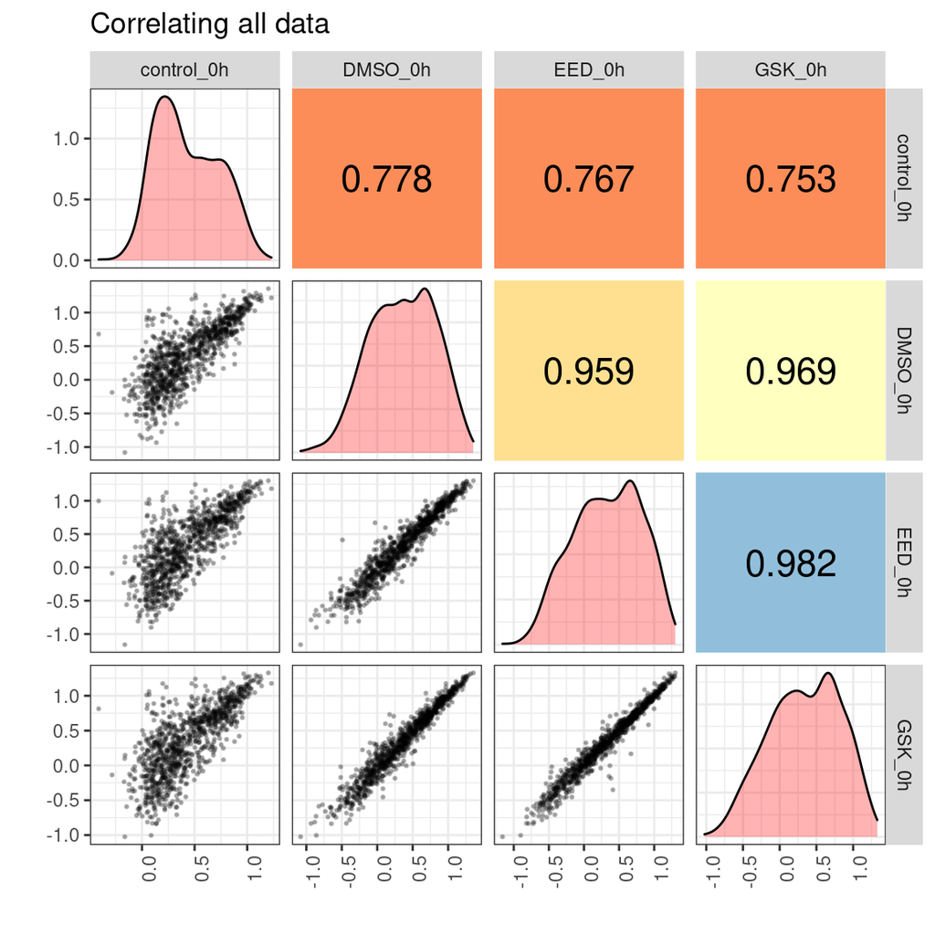

```r
# Also, only t=0h
#boundaries <- seq(from = 0.1, to = 0.98, length.out = 4)

# Replicates
tib_ggpairs <- tib %>%
  dplyr::select(contains("0h")) %>%
  drop_na()

plt <- ggpairs(tib_ggpairs,
               upper = list(continuous = corColor),
               lower = list(continuous = customScatter),
               diag = list(continuous = function(data, mapping, ...) {
                   ggally_densityDiag(data = data, mapping = mapping, alpha = 0.3, fill = "red") +
                   theme_bw()})) +
  ggtitle("Correlating all data") +
  xlab("") +
  ylab("") +
  theme(axis.text.x = element_text(angle = 90, hjust = 1))

print(plt)
```

I also tried to plot the LAD differences over time (24 h versus 0 h). As expected, auxin treatment results in similar differences in all conditions.

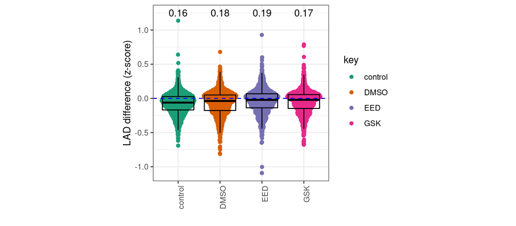

```r
# lad differences with control - should be small
tib %>%
  mutate(control = control_24h - control_0h,
         DMSO = DMSO_24h - DMSO_0h,
         GSK = GSK_24h - GSK_0h,
         EED = EED_24h - EED_0h) %>%
  dplyr::select(-ends_with("h"), -start, -end, -strand) %>%
  gather(key, value, -seqnames) %>%
  ggplot(aes(x = key, y = value, col = key)) +
  geom_quasirandom() +
  geom_boxplot(fill = NA, outlier.shape = NA, col = "black") +
  stat_summary(fun.data = sd_fun, geom = "text", col = "black") +
  geom_hline(yintercept = 0, col = "blue", linetype = "dashed") +
  xlab("") +
  ylab("LAD difference (z-score)") +
  scale_color_brewer(palette = "Dark2") +
  theme_bw() +
  theme(aspect.ratio = 1,
        axis.text.x = element_text(angle = 90, hjust = 1))
```

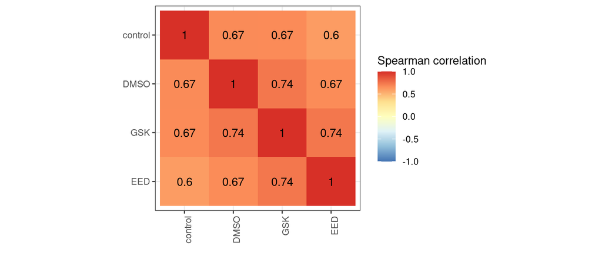

```r
# Correlation plot
tib_cor <- tib %>%
  mutate(control = control_24h - control_0h,
         DMSO = DMSO_24h - DMSO_0h,
         GSK = GSK_24h - GSK_0h,
         EED = EED_24h - EED_0h) %>%
  dplyr::select(-ends_with("h"), -start, -end, -strand, -seqnames) %>%
  drop_na() %>%
  correlate(method = "spearman") %>%
  gather(key, value, -term) %>%
  mutate(value = replace_na(value, 1)) %>%
  mutate(n1 = factor(term, levels(metadata_h3k27me3$condition)),
         n2 = factor(key, rev(levels(metadata_h3k27me3$condition))))

# Plot
plt <- tib_cor %>%
  ggplot(aes(x = n1, y = n2, fill = value, label = round(value, 2))) +
  geom_tile() +
  geom_text() +
  xlab("") + ylab("") +
  scale_fill_gradientn(colors = colorRampPalette(rev(brewer.pal(n = 7,
                                                                name = "RdYlBu")))(100),
                       limits = c(min(-1, tib_cor$value), 1),
                       name = "Spearman correlation") +
  theme_bw() +
  theme(aspect.ratio = 1,
        axis.text.x = element_text(angle = 90, hjust = 1))
plot(plt)
```

### 3. Example tracks

For presentation purposes, also generate some nice data tracks.

First load the H3K27me3 ChIP-seq data.

```r
# First, add binned h3k27me3 for data tracks
h3k27me3 <- import.bw("Data_NQ/ChIP_NQ/HistoneModifications/Public_2i_ChIP/E14_2i_H3K27me3_GSM2779214_SRR6025412-5_MQ15_sample.bw")

tmp <- tibble(bin = findOverlaps(h3k27me3, damid_h3k27me3,
                                 select = "first")) %>%
  mutate(score = h3k27me3$score,
         width = width(h3k27me3)) %>%
  # limit width to bin size
  mutate(width = ifelse(width > 10000, 10000, width)) %>%
  group_by(bin) %>%
  dplyr::summarise(mean = weighted.mean(score, width)) %>%
  ungroup() %>%
  drop_na()

# Prepare tibble
tib_damid <- as_tibble(damid_h3k27me3)
tib_damid$h3k27me3 <- NA
tib_damid$h3k27me3[tmp$bin] <- tmp$mean



# ts220208 - change the H3K27me3 tracks to the new data generated by NQ
GetBinnedH3K27me3 <- function(x) {

  h3k27me3 <- import.bw(x)

  tmp <- tibble(bin = findOverlaps(h3k27me3, damid_h3k27me3,
                                   select = "first")) %>%
    mutate(score = h3k27me3$score,
           width = width(h3k27me3)) %>%
    # limit width to bin size
    mutate(width = ifelse(width > 10000, 10000, width)) %>%
    group_by(bin) %>%
    dplyr::summarise(mean = weighted.mean(score, width)) %>%
    ungroup() %>%
    drop_na()

  # Prepare tibble
  tib_damid <- as_tibble(damid_h3k27me3)
  tib_damid$h3k27me3 <- NA
  tib_damid$h3k27me3[tmp$bin] <- tmp$mean

  tib_damid

}

tracks_h3k27me3 <- c("Data_NQ/ChIP_NQ/CTCF_depletion_H3K27me3/CTCF-AID_0h_r1_antiH3K27me3_sample.bw",
                     "Data_NQ/ChIP_NQ/CTCF_depletion_H3K27me3/CTCF-AID_0h_r2_antiH3K27me3_sample.bw",
                     "Data_NQ/ChIP_NQ/CTCF_depletion_H3K27me3/CTCF-AID_24h_r1_antiH3K27me3_sample.bw",
                     "Data_NQ/ChIP_NQ/CTCF_depletion_H3K27me3/CTCF-AID_24h_r2_antiH3K27me3_sample.bw")
tib_h3k27me3 <- purrr::map(tracks_h3k27me3,
                          GetBinnedH3K27me3)

# Combine these objects
tib_damid <- as_tibble(damid_h3k27me3) %>%
  add_column(h3k27me3_0h_r1 = tib_h3k27me3[[1]]$h3k27me3,
             h3k27me3_0h_r2 = tib_h3k27me3[[2]]$h3k27me3,
             h3k27me3_24h_r1 = tib_h3k27me3[[3]]$h3k27me3,
             h3k27me3_24h_r2 = tib_h3k27me3[[4]]$h3k27me3)

tib_damid$h3k27me3_0h <- rowMeans(tib_damid %>%
                                    dplyr::select(contains("h3k27me3_0h")),
                                  na.rm = T)
tib_damid$h3k27me3_24h <- rowMeans(tib_damid %>%
                                     dplyr::select(contains("h3k27me3_24h")),
                                   na.rm = T)

tib_damid <- tib_damid %>%
  dplyr::select(-contains("_r"))
```

And plot.

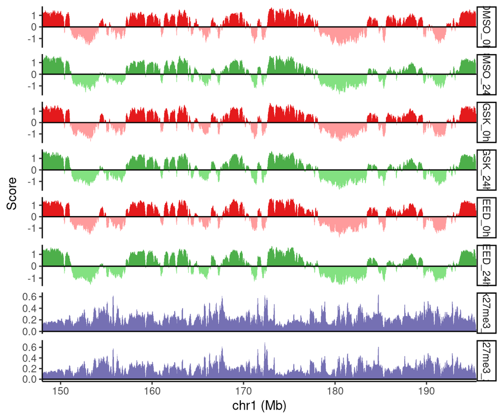

```r
PlotDataTracksLight <- function(input_tib, exp_names, centromeres,
                                color_groups, plot_chr = "chr1",
                                plot_start = 1, plot_end = 500e6,
                                smooth = 1, color_list = NULL,
                                fix_yaxis = F, aspect_ratio = NULL,
                                lighten_negative = T, raster = T) {

  # Get the scores for the samples
  tib_plot <- input_tib %>%
    dplyr::select(seqnames, start, end,
                  all_of(exp_names))

  if (smooth > 1) {
    tib_plot <- tib_plot %>%
      mutate_at(vars(matches("_|h3k27me3")),
                runmean, k = smooth)
  }

  # Filter for plotting window
  tib_plot <- tib_plot %>%
    filter(seqnames == plot_chr,
           start >= plot_start,
           end <= plot_end)

  # Gather
  tib_gather <- tib_plot %>%
    gather(key, value, -seqnames, -start, -end) %>%
    mutate(key = factor(key, levels = exp_names),
           fill_column = color_groups[match(key, names(color_groups))],
           fill_column = factor(fill_column, levels = unique(color_groups)))

  # If desired, make negative values a lighter shade to improve visualization
  if (lighten_negative) {
    tib_gather <- tib_gather %>%
      mutate(fill_column = interaction(fill_column,
                                       value < 0))
  }


  # Plot
  ylimits <- quantile(tib_gather$value, c(0.001, 0.999), na.rm = T)
  fill_column <- NULL

  plt <- tib_gather %>%
    ggplot(aes(fill = fill_column))


  # Rasterize plot to prevent Illustrator overload
  if (raster) {
    plt <- plt +
      rasterize(geom_rect(aes(xmin = start / 1e6, xmax = end / 1e6,
                              ymin = 0, ymax = value)),
                dpi = 300)
  } else {
    plt <- plt +
      geom_rect(aes(xmin = start / 1e6, xmax = end / 1e6,
                    ymin = 0, ymax = value))
  }

  plt <- plt +
    geom_hline(yintercept = 0, size = 0.5) +
    facet_grid(key ~ ., scales = "free_y") +
    xlab(paste0(plot_chr, " (Mb)")) +
    ylab("Score") +
    scale_x_continuous(expand = c(0, 0)) +
    scale_y_continuous(expand = c(0.025, 0.025)) +
    theme_classic()

  if (! is.null(color_list)) {

    if (lighten_negative) {
      color_list <- c(color_list,
                      lighten(color_list, amount = 0.5))
    }

    colors <- levels(tib_gather$fill_column)

    color_list <- color_list[1:length(colors)]
    names(color_list) <- colors
    #colors <- recode(colors, !!!color_list)

    plt <- plt +
      scale_fill_manual(values = color_list, guide = "none")
  } else {
    plt <- plt +
      scale_fill_brewer(palette = "Set1", guide = "none")
  }

  if (fix_yaxis) {
    plt <- plt +
      coord_cartesian(xlim = c(max(c(plot_start,
                                     min(tib_gather$start))) / 1e6,
                               min(c(plot_end,
                                     max(tib_gather$end))) / 1e6),
                      ylim = ylimits)
  } else {
    plt <- plt +
      coord_cartesian(xlim = c(max(c(plot_start,
                                     min(tib_gather$start))) / 1e6,
                               min(c(plot_end,
                                     max(tib_gather$end))) / 1e6))
  }

  if (! is.null(aspect_ratio)) {
    plt <- plt +
      theme(aspect.ratio = aspect_ratio)
  }

  plot(plt)

}


PlotDataTracksLight(input_tib = tib_damid,
                    exp_names = c("DMSO_0h",
                                  "DMSO_24h",
                                  "GSK_0h",
                                  "GSK_24h",
                                  "EED_0h",
                                  "EED_24h",
                                  "h3k27me3_0h",
                                  "h3k27me3_24h"),
                    color_groups = c(DMSO_0h = "0h",
                                     DMSO_24h = "24h",
                                     GSK_0h = "0h",
                                     GSK_24h = "24h",
                                     EED_0h = "0h",
                                     EED_24h = "24h",
                                     h3k27me3_0h = "h3k27me3",
                                     h3k27me3_24h = "h3k27me3"),
                    smooth = 9, plot_chr = "chr1", fix_yaxis = F,
                    plot_start = 148e6, plot_end = 205e6,
                    color_list = c(brewer.pal(3, "Set1")[c(1, 3)],
                                   "#7570B3"))
```

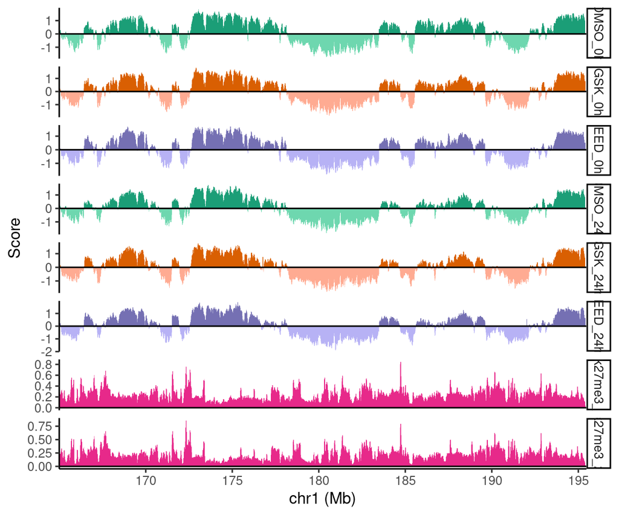

```r
PlotDataTracksLight(input_tib = tib_damid,
                    exp_names = c("DMSO_0h",
                                  "GSK_0h",
                                  "EED_0h",
                                  "DMSO_24h",
                                  "GSK_24h",
                                  "EED_24h",
                                  "h3k27me3_0h",
                                  "h3k27me3_24h"),
                    color_groups = c(DMSO_0h = "DMSO",
                                     GSK_0h = "GSK",
                                     EED_0h = "EED",
                                     DMSO_24h = "DMSO",
                                     GSK_24h = "GSK",
                                     EED_24h = "EED",
                                     h3k27me3_0h = "h3k27me3",
                                     h3k27me3_24h = "h3k27me3"),
                    smooth = 5, plot_chr = "chr1", fix_yaxis = F,
                    plot_start = 165e6, plot_end = 205e6,
                    color_list = brewer.pal(4, "Dark2"))
```

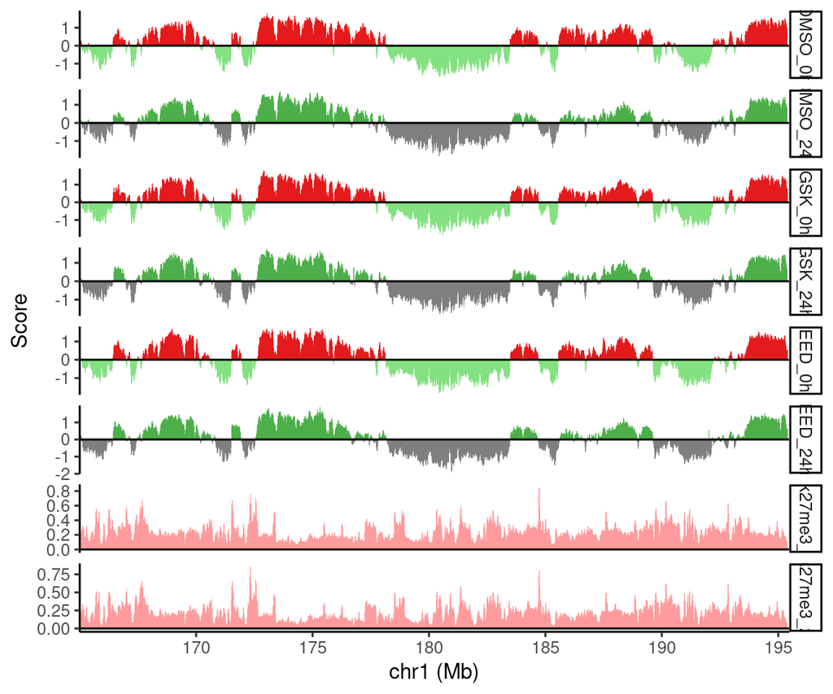

```r
PlotDataTracksLight(input_tib = tib_damid,
                    exp_names = c("DMSO_0h",
                                  "DMSO_24h",
                                  "GSK_0h",
                                  "GSK_24h",
                                  "EED_0h",
                                  "EED_24h",
                                  "h3k27me3_0h",
                                  "h3k27me3_24h"),
                    color_groups = c(DMSO_0h = "0h",
                                     DMSO_24h = "24h",
                                     GSK_0h = "0h",
                                     GSK_24h = "24h",
                                     EED_0h = "0h",
                                     EED_24h = "24h",
                                     h3k27me3_0h = "h3k27me3",
                                     h3k27me3_24h = "h3k27me3"),
                    smooth = 5, plot_chr = "chr1", fix_yaxis = F,
                    plot_start = 165e6, plot_end = 205e6,
                    color_list = brewer.pal(3, "Set1")[c(1, 3)])
```

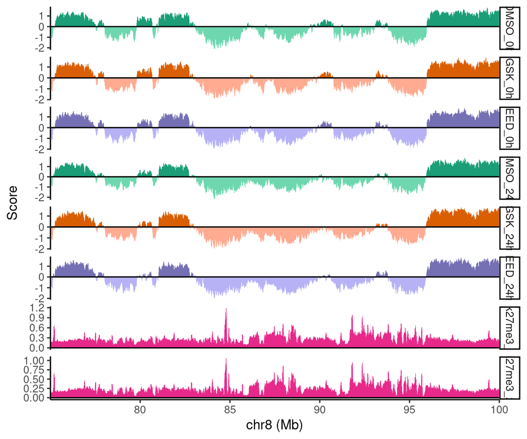

```r
PlotDataTracksLight(input_tib = tib_damid,
                    exp_names = c("DMSO_0h",
                                  "GSK_0h",
                                  "EED_0h",
                                  "DMSO_24h",
                                  "GSK_24h",
                                  "EED_24h",
                                  "h3k27me3_0h",
                                  "h3k27me3_24h"),
                    color_groups = c(DMSO_0h = "DMSO",
                                     GSK_0h = "GSK",
                                     EED_0h = "EED",
                                     DMSO_24h = "DMSO",
                                     GSK_24h = "GSK",
                                     EED_24h = "EED",
                                     h3k27me3_0h = "h3k27me3",
                                     h3k27me3_24h = "h3k27me3"),
                    smooth = 5, plot_chr = "chr8", fix_yaxis = F,
                    plot_start = 75e6, plot_end = 100e6,
                    color_list = brewer.pal(4, "Dark2"))
```

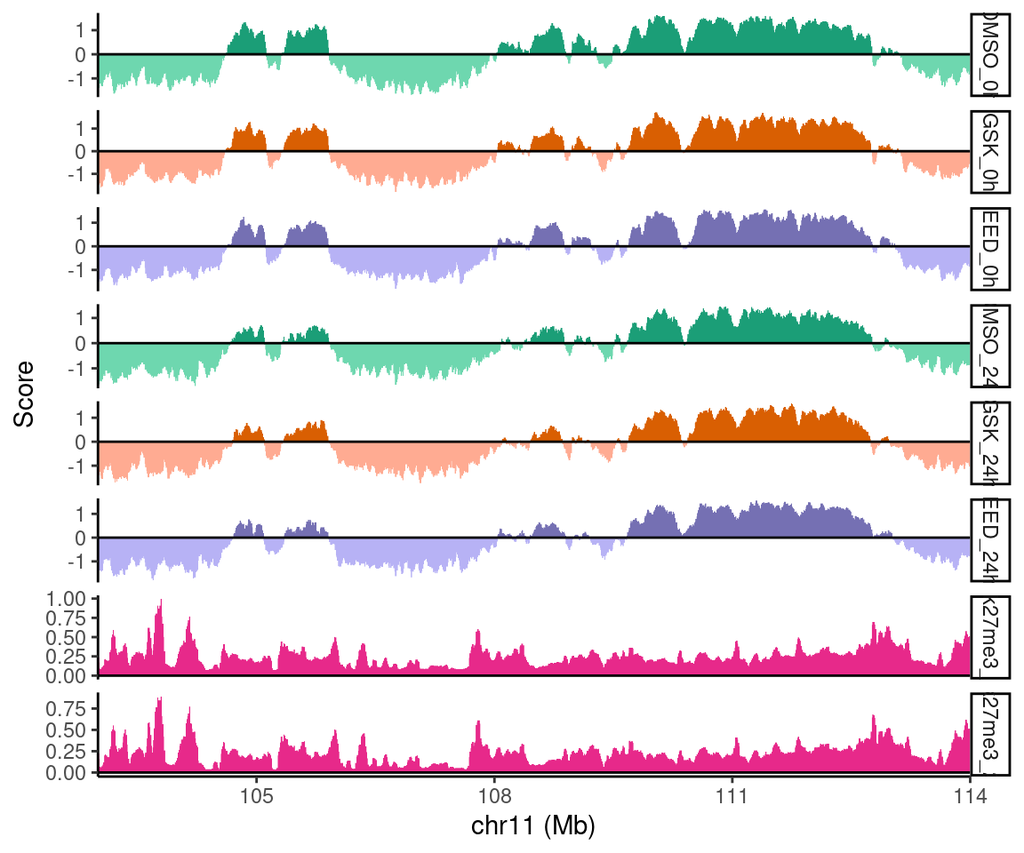

```r
PlotDataTracksLight(input_tib = tib_damid,
                    exp_names = c("DMSO_0h",
                                  "GSK_0h",
                                  "EED_0h",
                                  "DMSO_24h",
                                  "GSK_24h",
                                  "EED_24h",
                                  "h3k27me3_0h",
                                  "h3k27me3_24h"),
                    color_groups = c(DMSO_0h = "DMSO",
                                     GSK_0h = "GSK",
                                     EED_0h = "EED",
                                     DMSO_24h = "DMSO",
                                     GSK_24h = "GSK",
                                     EED_24h = "EED",
                                     h3k27me3_0h = "h3k27me3",
                                     h3k27me3_24h = "h3k27me3"),
                    smooth = 5, plot_chr = "chr11", fix_yaxis = F,
                    plot_start = 103e6, plot_end = 114e6,
                    color_list = brewer.pal(4, "Dark2"))
```

Looks good.

### 4. LAD differences versus h3k27me3 levels

Finally, I tried to determine the effect of H3K27me3 depletion on regions with actual H3K27me3 levels.

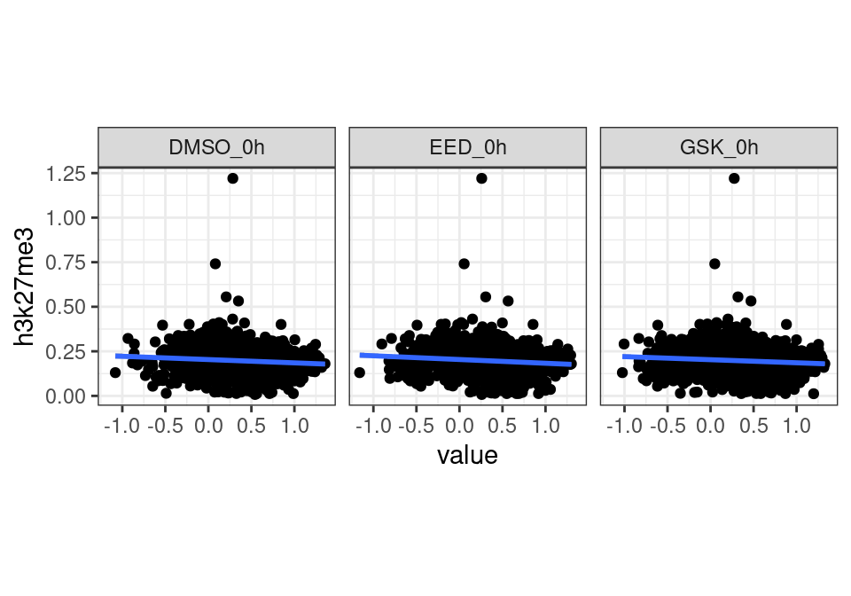

```r
# Add H3K27me3 to LAD scores
tmp <- as_tibble(findOverlaps(lad_scores, damid_h3k27me3)) %>%
  mutate(h3k27me3 = tib_damid$h3k27me3_0h[subjectHits]) %>%
  group_by(queryHits) %>%
  dplyr::summarise(h3k27me3 = mean(h3k27me3, na.rm = T)) %>%
  ungroup()

lad_scores$h3k27me3 <- tmp$h3k27me3
tib <- as_tibble(lad_scores)

# LAD scores versus H3K27me3
tib %>%
  gather(key, value, contains("0h"), -contains("control")) %>%
  ggplot(aes(x = value, y = h3k27me3)) +
  geom_point() +
  geom_smooth(method = "lm") +
  facet_grid(. ~ key) +
  theme_bw() +
  theme(aspect.ratio = 1)
```

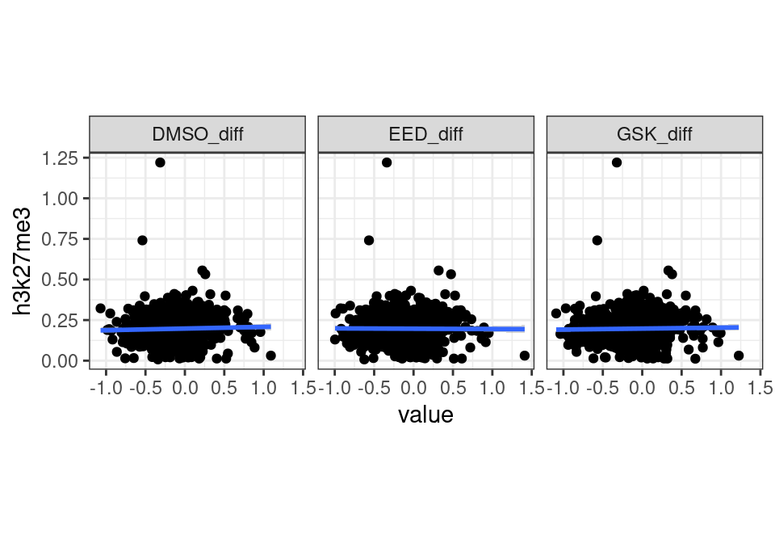

```r
# Difference in LAD versus h3k27me3 score
tib %>%
  mutate(DMSO_diff = DMSO_0h - control_0h,
         GSK_diff = GSK_0h - control_0h,
         EED_diff = EED_0h - control_0h) %>%
  gather(key, value, contains("diff")) %>%
  ggplot(aes(x = value, y = h3k27me3)) +
  geom_point() +
  geom_smooth(method = "lm") +
  facet_grid(. ~ key) +
  theme_bw() +
  theme(aspect.ratio = 1)
```

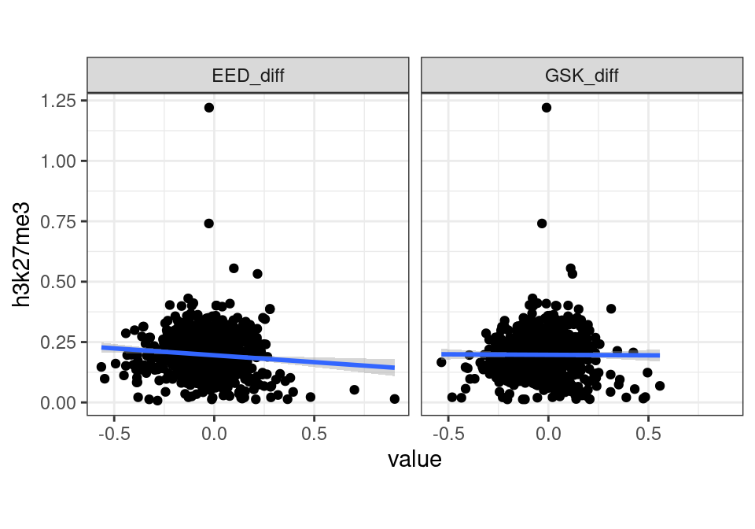

```r
tib %>%
  mutate(GSK_diff = GSK_0h - DMSO_0h,
         EED_diff = EED_0h - DMSO_0h) %>%
  gather(key, value, contains("diff")) %>%
  ggplot(aes(x = value, y = h3k27me3)) +
  geom_point() +
  geom_smooth(method = "lm") +
  facet_grid(. ~ key) +
  theme_bw() +
  theme(aspect.ratio = 1)
```

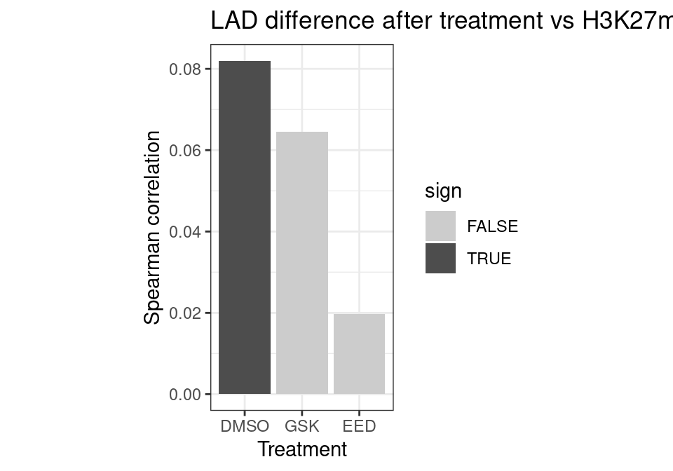

```r
# Correlate change after H3K27me3 depletion versus initial H3K27me3
tib %>%
  mutate(DMSO_diff = DMSO_0h - control_0h,
         GSK_diff = GSK_0h - control_0h,
         EED_diff = EED_0h - control_0h) %>%
  drop_na() %>%
  gather(key, value, contains("diff")) %>%
  group_by(key) %>%
  dplyr::summarise(cor = cor(value, h3k27me3, method = "spearman"),
                   test = cor.test(value, h3k27me3, method = "spearman")$p.value) %>%
  mutate(padj = p.adjust(test),
         sign = padj < 0.05,
         key = str_remove(key, "_diff"),
         key = factor(key, c("DMSO", "GSK", "EED"))) %>%
  ggplot(aes(x = key, y = cor, fill = sign)) +
  geom_bar(stat = "identity") +
  xlab("Treatment") +
  ylab("Spearman correlation") +
  ggtitle("LAD difference after treatment vs H3K27me3") +
  scale_fill_manual(values = c("grey80", "grey30")) +
  theme_bw() +
  theme(aspect.ratio = 2)
```

### Save data

Save the data.

```r
# Save .rds files
saveRDS(metadata_h3k27me3,
        file.path(output.dir, "metadata_h3k27me3.rds"))
saveRDS(damid_h3k27me3,
        file.path(output.dir, "damid_h3k27me3.rds"))


# Also, as tsv file
tib_damid <- as_tibble(damid_h3k27me3) %>%
  dplyr::select(-width, -strand) %>%
  dplyr::select(-contains("control"))
print(names(tib_damid))
```

```
## [1] "seqnames" "start"    "end"      "DMSO_0h"  "DMSO_24h" "EED_0h"   "EED_24h"
## [8] "GSK_0h"   "GSK_24h"
```

```r
write_tsv(tib_damid,
          file.path(output.dir, "damid_h3k27me3_depletion_average_replicates.tsv"))
```

### Conclusion

LAD patterns are not affected by H3K27me3 inhibition. There is also no effect of the combination of CTCF depletion and H3K27me3 inhibition.